# R Notebook

```r
library(dplyr)
library(ggplot2)
library(gridExtra)
library(MASS)
library(fitdistrplus)
library(ggstatsplot)
library(tibble)
library(readr)
```

# Proyecto de modelación integrado en etapas dentro de la notebook

## Etapa 1 - definición de los datos expuestos y no expuestos

Esta parte realiza la lectura de datos y los convierte en trame

```r
# confusoras DAG= "sl2l_qa", "sl2l_iso","ecpl_qa", "ecpl_iso","age", "gender_F",
# features predictoras = "sl2l_diameter","ccbd_diameter","ifol_diameter","ecpl_volume","tral_volume","sl2l_mean_length","ccbd_mean_length"

setwd("C:/hcgalvan/Repositorios/hcgalvan_project/data/union/End")
temp = gsub(".*target.*", "", readLines("integrado.csv"))
data<-read.table(text=temp, sep=",", header=TRUE)

t<-data.frame(data[,c("sl2l_diameter","ccbd_diameter","ifol_diameter","ecpl_volume","tral_volume","sl2l_mean_length","ccbd_mean_length","label","sl2l_qa", "sl2l_iso","ecpl_qa", "ecpl_iso","age", "gender_F")])

t$gend_F <- ifelse(t$gender_F == "True", 1, 0) #convierto en = o 1
t <- subset(t, select = -c(gender_F)) # Quito de tabla
```

### Creación de features expuestos y no expuestos

Definición de nuevas variables como Expuesto y no Expuesto Se realizó estudio de cada variable: Su real distribución empírica Esta distribución se obtiene de los sujetos de control. las constantes definidas son el 1ero y 3er cuartil obtenida de distribución de densidad

False = No Expuesto = 0; True = Expuesto = 1

```r
t<- t %>%
  mutate(sl2ldmExp = if_else((t$sl2l_diameter > 22.10 & t$sl2l_diameter < 24.42), 0, 1))

t<- t %>%
  mutate(ccbdmExp = if_else((t$ccbd_diameter > 26.07 & t$ccbd_diameter < 30.23), 0, 1))

t<- t %>%
  mutate(ifoldmExp = if_else((t$ifol_diameter > 14.68 & t$ifol_diameter < 16.51), 0, 1))

t<- t %>%
  mutate(ecplvlExp = if_else((t$ecpl_volume > 6455 & t$ecpl_volume < 8918), 0, 1))

t<- t %>%
  mutate(tralvlExp = if_else((t$tral_volume > 12366 & t$tral_volume < 18004), 0, 1))

t<- t %>%
  mutate(sl2lmlExp = if_else((t$sl2l_mean_length > 72.18 & t$sl2l_mean_length < 80.61), 0, 1))

t<- t %>%
  mutate(ccbdmlExp = if_else((t$ccbd_mean_length > 112.62 & t$ccbd_mean_length < 123.81), 0, 1))
```

### Guardar datos para su estudio en InfoStat

El estudio que realizo en InfoStat es para determinar que variable predictora debe estar en la regresión y continuar el estudio por R. InfoStat me arroja rapidamente cuales son las confusoras más importantes

Dependerá de variable A y las confusoras.

```r
write.csv(t, "C:\\hcgalvan\\Repositorios\\hcgalvan_project\\data\\union\\End\\dbfmodelo.csv", row.names=FALSE)
```

### Creación de variable A a partir de los expuestos y no expuestos

OPCION 1: Variable con A con 5 features filtrados como expuestos.

t<- t %>% mutate(A = if_else((t$sl2ldmExp==1 & t$sl2lmlExp==1 & t$ccbdmExp==1 & t$ccbdmlExp==1 & t$tralvlExp==1),1, 0)) # No agrego ecpl porque contiene mucho ruido

t<- t %>% mutate(A = if_else((t$sl2ldmExp==1 & t$sl2lmlExp==1 & t$ccbdmExp==1 & t$ccbdmlExp==1 & t$tralvlExp==1 & t$ifoldmExp ==1),1, 0)) # No agrego ecpl porque contiene mucho ruido filter(t, A==1)

OPCION 3: Variable A Con una sola variable filtrada

```r
t<- t %>%
  mutate(A = if_else(t$sl2ldmExp==1,1, 0))
```

```r
t$Esquiz <- ifelse(t$label == 0, "SI", "NO")
t$sl2sdmd <- ifelse(t$sl2ldmExp == 0, "NO", "SI")
########################
xtabs(~sl2sdmd+Esquiz,t) #table of counts per stratum
```

```
       Esquiz
sl2sdmd NO SI
     NO 23 15
     SI 27 31
```

```r
odd <- ((31/27)/(15/23))
p <- (46/(23+15+27+31))
sprintf("odd: %f", odd)
```

```
[1] "odd: 1.760494"
```

```r
sprintf("log odd: %f", log(odd))
```

```
[1] "log odd: 0.565594"
```

```r
sprintf("Prob(Ezq): %f", p)
```

```
[1] "Prob(Ezq): 0.479167"
```

```r
v1 <- p*(27+31)
v2 <- (27+31)-v1
v3 <- p*(23+15)
v4 <- (23+15)-v3
pval <- 1-((v1/v2)/(v3/v3))
pval
```

```
[1] 0.08
```

```r
((11.2/128.8)/(198.7/17.3))
```

```
[1] 0.00757095
```

```r
########################
t$ccbdmd <- ifelse(t$ccbdmExp == 0, "NO", "SI")
xtabs(~ccbdmd+Esquiz,t) #table of counts per stratum
```

```
      Esquiz
ccbdmd NO SI
    NO 25 22
    SI 25 24
```

```r
odd <- ((24/25)/(22/25)) ### ERROR
p <- (46/(50))
sprintf("odd: %f", odd)
```

```
[1] "odd: 1.090909"
```

```r
sprintf("log odd: %f", log(odd))
```

```
[1] "log odd: 0.087011"
```

```r
sprintf("Prob(Ezq): %f", p)
```

```
[1] "Prob(Ezq): 0.920000"
```

```r
########################
t$ifoldmd <- ifelse(t$ifoldmExp == 0, "NO", "SI")
xtabs(~ifoldmd+Esquiz,t) #table of counts per stratum
```

```
       Esquiz
ifoldmd NO SI
     NO 23 16
     SI 27 30
```

```r
odd <- ((27/30)/(16/23)) ### ERROR
p <- ((27+16)/(30+23))
sprintf("odd: %f", odd)
```

```
[1] "odd: 1.293750"
```

```r
sprintf("log odd: %f", log(odd))
```

```
[1] "log odd: 0.257545"
```

```r
sprintf("Prob(Ezq): %f", p)
```

```
[1] "Prob(Ezq): 0.811321"
```

```r
########################
t$sl2lmld <- ifelse(t$sl2lmlExp == 0, "NO", "SI")
xtabs(~sl2lmld+Esquiz,t) #table of counts per stratum
```

```
       Esquiz
sl2lmld NO SI
     NO 25 22
     SI 25 24
```

```r
odd <- ((24/25)/(22/25)) ### ERROR
p <- ((24+22)/(25+25))
sprintf("odd: %f", odd)
```

```
[1] "odd: 1.090909"
```

```r
sprintf("log odd: %f", log(odd))
```

```
[1] "log odd: 0.087011"
```

```r
sprintf("Prob(Ezq): %f", p)
```

```
[1] "Prob(Ezq): 0.920000"
```

```r
########################
t$ecplvld <- ifelse(t$ecplvlExp == 0, "NO", "SI")
xtabs(~ecplvld+Esquiz,t) #table of counts per stratum
```

```
       Esquiz
ecplvld NO SI
     NO 26 16
     SI 24 30
```

```r
odd <- ((30/24)/(16/26)) ### ERROR
p <- ((30+16)/(24+26))
sprintf("odd: %f", odd)
```

```
[1] "odd: 2.031250"
```

```r
sprintf("log odd: %f", log(odd))
```

```
[1] "log odd: 0.708651"
```

```r
sprintf("Prob(Ezq): %f", p)
```

```
[1] "Prob(Ezq): 0.920000"
```

```r
########################
t$tralvld <- ifelse(t$tralvlExp == 0, "NO", "SI")
xtabs(~tralvld+Esquiz,t) #table of counts per stratum
```

```
       Esquiz
tralvld NO SI
     NO 24 19
     SI 26 27
```

```r
odd <- ((27/26)/(19/24)) ### ERROR
p <- ((27+19)/(26+24))
sprintf("odd: %f", odd)
```

```
[1] "odd: 1.311741"
```

```r
sprintf("log odd: %f", log(odd))
```

```
[1] "log odd: 0.271355"
```

```r
sprintf("Prob(Ezq): %f", p)
```

```
[1] "Prob(Ezq): 0.920000"
```

```r
########################
t$ccbdmld <- ifelse(t$ccbdmlExp == 0, "NO", "SI")
xtabs(~ccbdmld+Esquiz,t) #table of counts per stratum
```

```
       Esquiz
ccbdmld NO SI
     NO 24 13
     SI 26 33
```

```r
odd <- ((33/26)/(13/24)) ### ERROR
p <- ((33+13)/(26+24))
sprintf("odd: %f", odd)
```

```
[1] "odd: 2.343195"
```

```r
sprintf("log odd: %f", log(odd))
```

```
[1] "log odd: 0.851515"
```

```r
sprintf("Prob(Ezq): %f", p)
```

```
[1] "Prob(Ezq): 0.920000"
```

## Etapa 2: Regresion Logística con PCA - Expuestos (A)

Por lo que está sucediendo con los datos cuando trabajamos por features como A, y no en su conjunta, es que vamos a necesitar utilizar PCA para que pueda tener predictoras más ajustadas, que solo las elegidas. Esto se puede observar en la regresión logística obtenida, ya que no supera los p-value correctos. Es decir, no converge.

```r
t2 <- dplyr::select(dplyr::filter(data, label == 0), "sl2l_diameter","sl2l_qa", "sl2l_iso", "ccbd_iso", "ccbd_qa", "ifol_qa", "ifol_iso", "ecpl_qa", "ecpl_iso", "tral_qa", "tral_iso", "afsl_qa", "afsl_iso", "afsr_qa", "afsr_iso", "cfpl_iso", "cfpl_qa", "cfpr_iso", "cfpr_qa", "fatl_iso", "fatl_qa", "fatr_iso", "fatr_qa", "slfl_iso", "slfl_qa", "slfr_iso", "slfr_qa", "tral_iso", "tral_qa", "ufsl_iso", "ufsl_qa", "ufsr_iso", "ufsr_qa", "age", "gender_F")

## Creo variable gender en una sola variable
t2$gend_F <- ifelse(t2$gender_F == "True", 1, 0) #convierto en = o 1
t2 <- subset(t2, select = -c(gender_F)) # Quito de tabla

##Creo la variable A desde sl2l_diameter
t2<- t2 %>%
  mutate(A = if_else((t2$sl2l_diameter > 22.10 & t2$sl2l_diameter < 24.42), 0, 1))
t2 <- subset(t2, select = -c(sl2l_diameter)) # Quito de tabla

t2
```

|  | sl2l_qa | sl2l_iso | ccbd_iso | ccbd_qa | ifol_qa | ifol_iso | ecpl_qa | ecpl_iso | tral_qa | tral_iso | afsl_qa | afsl_iso | afsr_qa | afsr_iso | cfpl_iso | cfpl_qa | cfpr_iso | cfpr_qa | fatl_iso | fatl_qa | fatr_iso | fatr_qa | slfl_iso | slfl_qa | slfr_iso | slfr_qa | ufsl_iso | ufsl_qa | ufsr_iso | … |
| --- | --- | --- | --- | --- | --- | --- | --- | --- | --- | --- | --- | --- | --- | --- | --- | --- | --- | --- | --- | --- | --- | --- | --- | --- | --- | --- | --- | --- | --- | --- |
| 1 | 0.0909480 | 0.233848 | 0.210085 | 0.112881 | 0.1078920 | 0.2259630 | 0.1059280 | 0.2469190 | 0.0811560 | 0.2064530 | 0.1069880 | 0.2714450 | 0.0849187 | 0.271885 | 0.2026000 | 0.1147290 | 0.1965860 | 0.1056410 | 0.262141 | 0.0948509 | 0.254176 | 0.0843324 | 0.4401969 | 0.1797773 | 0.4451154 | 0.1798766 | 0.2771080 | 0.0819150 | 0.2669930 | … |
| 2 | 0.1894720 | 0.520475 | 0.533948 | 0.276873 | 0.2271730 | 0.4739680 | 0.1956250 | 0.5359360 | 0.1710570 | 0.4571390 | 0.1932270 | 0.5979930 | 0.1804250 | 0.699567 | 0.4994770 | 0.2509900 | 0.5593750 | 0.2103680 | 0.642592 | 0.1646420 | 0.689653 | 0.1616650 | 0.5956690 | 0.2002290 | 0.6693940 | 0.1810080 | 0.7338460 | 0.1332830 | 0.8456430 | … |
| 3 | 0.1992660 | 0.593726 | 0.532244 | 0.264001 | 0.2473140 | 0.5107710 | 0.2465280 | 0.5964530 | 0.1432830 | 0.4202300 | 0.2975380 | 0.7533400 | 0.2539770 | 0.725157 | 0.5773220 | 0.2893140 | 0.5750710 | 0.2730400 | 0.599022 | 0.2350070 | 0.622188 | 0.2345190 | 0.6348080 | 0.2631670 | 0.4451154 | 0.1798766 | 0.6305520 | 0.2061970 | 0.6589500 | … |
| 4 | 0.0847333 | 0.219200 | 0.221928 | 0.116467 | 0.0961663 | 0.1977590 | 0.1934443 | 0.5146577 | 0.0733201 | 0.1879750 | 0.0978504 | 0.2700530 | 0.0891912 | 0.235669 | 0.2086780 | 0.1110940 | 0.1967820 | 0.0988454 | 0.263788 | 0.0862765 | 0.255845 | 0.0801434 | 0.2326080 | 0.0915498 | 0.2015530 | 0.0918881 | 0.2692500 | 0.0837505 | 0.2760290 | … |
| 5 | 0.1315480 | 0.368871 | 0.340954 | 0.176369 | 0.1559800 | 0.3431200 | 0.1408350 | 0.3369140 | 0.1006430 | 0.2758230 | 0.1415440 | 0.3753720 | 0.1390310 | 0.414959 | 0.3123040 | 0.1521240 | 0.3181260 | 0.1407440 | 0.381064 | 0.1332270 | 0.372183 | 0.1291590 | 0.3390360 | 0.1378800 | 0.3420110 | 0.1252200 | 0.3840450 | 0.1137800 | 0.4084880 | … |
| 6 | 0.1179450 | 0.300981 | 0.295878 | 0.157817 | 0.1424190 | 0.2746920 | 0.1934443 | 0.5146577 | 0.1004610 | 0.2575310 | 0.1272510 | 0.3004420 | 0.1266340 | 0.323218 | 0.2441550 | 0.1336410 | 0.2367140 | 0.1317600 | 0.293172 | 0.0948636 | 0.295469 | 0.0893513 | 0.3139970 | 0.1291270 | 0.3085070 | 0.1211710 | 0.3106030 | 0.0834543 | 0.3070040 | … |
| 7 | 0.1801580 | 0.466052 | 0.433923 | 0.221938 | 0.2220510 | 0.4187790 | 0.1829540 | 0.4794690 | 0.1523850 | 0.3886160 | 0.1855200 | 0.5231160 | 0.1846530 | 0.506399 | 0.4130180 | 0.2276870 | 0.3730950 | 0.2054940 | 0.516950 | 0.1687870 | 0.427214 | 0.1576101 | 0.5596260 | 0.1943580 | 0.4975700 | 0.1744670 | 0.5211610 | 0.1555600 | 0.5686500 | … |
| 8 | 0.2050960 | 0.548065 | 0.482541 | 0.238590 | 0.2256850 | 0.5091730 | 0.1934443 | 0.5146577 | 0.1760090 | 0.4868080 | 0.1965520 | 0.5319680 | 0.1893770 | 0.585220 | 0.4623610 | 0.2178770 | 0.4317800 | 0.2034340 | 0.556718 | 0.1679650 | 0.546856 | 0.1689920 | 0.5843560 | 0.1927440 | 0.5380390 | 0.1828600 | 0.7574860 | 0.1623290 | 0.6531050 | … |
| 9 | 0.1392640 | 0.368971 | 0.328662 | 0.178022 | 0.1552470 | 0.3134010 | 0.1934443 | 0.5146577 | 0.1074130 | 0.2902880 | 0.2100160 | 0.4954740 | 0.2151530 | 0.577510 | 0.4014560 | 0.2117520 | 0.4077630 | 0.2003370 | 0.505175 | 0.1684910 | 0.527358 | 0.1755720 | 0.5044300 | 0.1896550 | 0.5107360 | 0.1975960 | 0.5359930 | 0.1400350 | 0.5345630 | … |
| 10 | 0.2165580 | 0.536278 | 0.506190 | 0.260240 | 0.2340120 | 0.4669580 | 0.2167440 | 0.5421990 | 0.1825180 | 0.4533320 | 0.1938420 | 0.5141680 | 0.1978200 | 0.526770 | 0.4350510 | 0.2064230 | 0.3952880 | 0.2011040 | 0.538125 | 0.1823560 | 0.546691 | 0.1799580 | 0.5272560 | 0.2092120 | 0.4907180 | 0.1871250 | 0.5789340 | 0.1513490 | 0.5472390 | … |

[output cut: 36 more lines]

### FORMA 2 Reg Logística con PCA para Expuestas

```r
pca.out2 <- prcomp(t2[,c(-33)],
                  scale. = TRUE)
pca.out2$x
pca.var2 <- pca.out2$sdev^2  #autovalores
pca.var2
misdatos <- data.frame(A = t2[, "A"], pca.out2$x[, 1:2])
pca.out2[1]
logRegPCA <- glm(A ~ .,  data = misdatos, family = binomial)
#summary(logRegPCA)
logistic.regression.or.ci(logRegPCA)
summary(logRegPCA)$coefficients
```

[output not shown]

### Reg Logística con PCA para No expuestas

```r
pca.out3 <- prcomp(t3[,c(-33)],
                  scale. = TRUE)
pca.out3$x
pca.var3 <- pca.out3$sdev^2  #autovalores
pca.var3
misdatos2 <- data.frame(A = t3[, "A"], pca.out3$x[, 1:2])
pca.out3[1]
logRegPCANoExp <- glm(A ~ .,  data = misdatos2, family = binomial)
#summary(logRegPCA)
logistic.regression.or.ci(logRegPCANoExp)
summary(logRegPCANoExp)$coefficients
```

[output not shown]

## Etapa 2: Generación Propensity Z score

Aquí es un trabajo manual para cada prueba a realizar. Cada regresión tiene que ser ajustada.

### Generación de Z Score

Usar una de ellas. La que mejor se ajusta a los datos.

### Con PCA

```r
############## PARA EXPUESTAS #######################
zscores<-c()
for(i in 1:46) {       # for-loop over rows
    zscores[i] <-((1/(1+exp(-(as.numeric(unlist(logRegPCA$coefficients[1]))+as.numeric(unlist(logRegPCA$coefficients[2]))*as.numeric(unlist(pca.out2$x[i,"PC1"]))+as.numeric(unlist(logRegPCA$coefficients[3]))*as.numeric(unlist(pca.out2$x[i,"PC2"])))))))
}
t2$zscore <-zscores
############## PARA EXPUESTAS #######################
zscores2<-c()
for(i in 1:50) {       # for-loop over rows
    zscores2[i] <-((1/(1+exp(-(as.numeric(unlist(logRegPCANoExp$coefficients[1]))+as.numeric(unlist(logRegPCANoExp$coefficients[2]))*as.numeric(unlist(pca.out3$x[i,"PC1"]))+as.numeric(unlist(logRegPCANoExp$coefficients[3]))*as.numeric(unlist(pca.out3$x[i,"PC2"])))))))
}
t3$zscore <-zscores2
```

#### Armado de Subclases del Zscore para estudio posterior

Tener en cuenta que se puede dividir de manera diferente, por otra cantidad de estratos como por ejemplo spline.

```r
xtabs(~A+subclass,t2) #table of counts per stratum
```

```
   subclass
A   1 2 3 4 5
  0 4 4 3 3 1
  1 6 4 9 5 7
```

```r
xtabs(~A+subclass,t3) #table of counts per stratum
```

```
   subclass
A    1  2  3  4  5
  0 22  1  0  0  0
  1 25  2  0  0  0
```

```r
write.csv(t2, "C:\\hcgalvan\\Repositorios\\hcgalvan_project\\data\\union\\End\\dbcasespieceswice.csv", row.names=FALSE) ##guardo los casos
write.csv(t3, "C:\\hcgalvan\\Repositorios\\hcgalvan_project\\data\\union\\End\\dbcontrolpieceswice.csv", row.names=FALSE) ##guardo los sujetos de control
```

### Espacio para utilizar con función constante por partes.

```r
setwd("C:/hcgalvan/Repositorios/hcgalvan_project/data/union/End")
temp = gsub(".*target.*", "", readLines("dbcasespieceswice.csv"))
data<-read.table(text=temp, sep=",", header=TRUE)
dz<-data.frame(data[,c("D","A","zscore","subclass")])
pcwstd<-data.frame(dz)
```

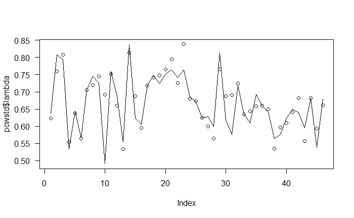

```r
deri_pol1 <- function(x){-6.122264 + 17.67111*x - 18.56562*x^2 + 10.44433*x^3 - 3.536183*x^4 + 0.7576271*x^5 - 0.1036324*x^6 + 0.008774759*x^7 - 0.000418757*x^8 + 8.6019e-06*x^9}

deri_pol2 <- function(x){-0.2197296 + 2.0046*x - 1.811326*x^2 + 0.8375173*x^3 - 0.2182443*x^4 + 0.03246031*x^5 - 0.002569767*x^6 + 8.38559e-05*x^7}

deri_pol3 <- function(x){4.793893 - 11.81498*x + 14.1384*x^2 - 9.532235*x^3 + 4.068752*x^4 - 1.159912*x^5 + 0.2257844*x^6 -  0.03004852*x^7 + 0.002683565*x^8 - 0.0001534813*x^9 + 5.071574e-06*x^10 - 7.35409e-08*x^11 }

deri_pol4 <- function(x){2.512275 - 4.393058*x + 4.022133*x^2 - 1.838199*x^3 + 0.4632213*x^4 - 0.06537888*x^5 + 0.004842031*x^6 - 0.0001464992*x^7}

deri_pol5 <- function(x){-4.94969 + 13.71929*x - 12.46775*x^2 + 5.722334*x^3 - 1.45807*x^4 + 0.2089239*x^5 - 0.01574029*x^6 + 0.0004847141*x^7}

### Obtengo los límites de zscore a partir del filtro subclase y utilizar en la función por partes

lim1 <- max(as.numeric(unlist(dplyr::select(dplyr::filter(pcwstd, subclass == 1,),"zscore"))))
lim2 <- max(as.numeric(unlist(dplyr::select(dplyr::filter(pcwstd, subclass == 2,),"zscore"))))
lim3 <- max(as.numeric(unlist(dplyr::select(dplyr::filter(pcwstd, subclass == 3,),"zscore"))))
lim4 <- max(as.numeric(unlist(dplyr::select(dplyr::filter(pcwstd, subclass == 4,),"zscore"))))
lim5 <- max(as.numeric(unlist(dplyr::select(dplyr::filter(pcwstd, subclass == 5,),"zscore"))))


posicionax <- function(x, pos){
  v <- NULL
  h <- NULL
  h<-as.numeric(unlist(dplyr::select(dplyr::filter(pcwstd, subclass == pos,),"zscore")))
  div.1 <- round((h[order(h, decreasing = FALSE)] / x),4)
  v<- which(div.1 == 1.0000,)
  v
}

buscarx <- function(x){
    d <- NULL
    ifelse (x > 0 & x<= lim1, d <- posicionax(x, 1), 0)
    ifelse (x>lim1 & x<=lim2, d <- posicionax(x, 2), 0)
    ifelse (x>lim2 & x<=lim3, d <- posicionax(x, 3), 0)
    ifelse (x>lim3 & x<=lim4, d <- posicionax(x, 4), 0)
    ifelse (x>lim4, d <- posicionax(x, 5), 0)
    d
}

fx <- function(x, dat){
    f <- NULL
    ifelse (x > 0 & x<= lim1, f <- deri_pol1(dat), 0)
    ifelse (x>lim1 & x<=lim2, f <- deri_pol2(dat), 0)
    ifelse (x>lim2 & x<=lim3, f <- deri_pol3(dat), 0)
    ifelse (x>lim3 & x<=lim4, f <- deri_pol4(dat), 0)
    ifelse (x>lim4, f <- deri_pol5(dat), 0)
    f
}

x <- data.frame(pcwstd$zscore)
for(i in 1:nrow(x)) {       # for-loop over rows
  dat <- buscarx(pcwstd$zscore[[i]])
  #print(dat)
  #print(fx(pcwstd$zscore[[i]], dat))
  lambd <-fx(pcwstd$zscore[[i]], dat)
  pcwstd$lambda[i] <- lambd
  }

plot(pcwstd$lambda, type="l", las=1)
points(x)
```

```r
NA
NA
```

#### Generar Constante Delta

Se utiliza o genera despues de realizar la regresión

```r
delta
```

```
[1] 1.28239
```

## Modelo Final

El modelo final tiene algunas dificultades, con respecto a si es por cada sujeto o es el total de sujetos.

Deberíamos tener dos calculos

[figure not shown]